# Food Delivery Cost and Profitability Analysis using Python

Want to understand how profitable your food delivery service is? This analysis dives deep into the financial health of your operation, pinpointing ways to cut costs, boost revenue, and optimize pricing strategies. By the end, you'll have the tools to perform a food delivery cost and profitability analysis using Python – perfect for anyone looking to improve their bottom line.

### Unveiling the Profitability of Food Delivery:

To understand how much money your food delivery service makes, we need to examine all its expenses. This includes direct costs like delivery fees and packaging, as well as indirect costs like customer discounts and restaurant commissions. By comparing these costs to the revenue earned (mainly from order value and commission fees), we can determine the profitability of each order.

Here's how we can conduct a Food Delivery Cost and Profitability Analysis:

1. Data Collection: We begin by gathering detailed information about every aspect of your food delivery operations.
2. Data Cleaning: This data might have inconsistencies, missing entries, or irrelevant details. We'll clean it up to ensure accuracy.
3. Feature Engineering: We'll identify specific factors within the data that can impact your costs and profits.
4. Cost Breakdown: We'll categorize all the costs associated with each order. This includes fixed costs (like packaging) and variable costs (like delivery fees and discounts).
5. Revenue Analysis: We'll determine the revenue generated from each order, focusing on commission fees and the order value before any discounts are applied.
6. Profitability Assessment: For each order, we'll calculate the profit by subtracting the total costs from the revenue. Analyzing this data will reveal trends in profitability across all orders.
7. Strategic Recommendations: Based on the analysis, we'll develop strategies to improve your profitability.
8. Financial Impact Simulation: We'll use the data to predict the financial outcome of proposed changes, such as adjusting discount or commission rates.

This process starts with collecting a high-quality dataset, and I've found the perfect one for this task!You can download the dataset from [here](https://statso.io/optimizing-cost-and-profitability-case-study/).

### Food Delivery Cost and Profitability Analysis using Python

Now, let’s get started with the task of Food Delivery Cost and Profitability Analysis by importing the necessary Python libraries and the dataset:

```python
import pandas as pd
pd.set_option('display.max_columns', None)
food_orders = pd.read_csv("food_orders_new_delhi.csv")
print(food_orders.head())
```

```
   Order ID Customer ID Restaurant ID  Order Date and Time  \
0         1       C8270         R2924  2024-02-01 01:11:52
1         2       C1860         R2054  2024-02-02 22:11:04
2         3       C6390         R2870  2024-01-31 05:54:35
3         4       C6191         R2642  2024-01-16 22:52:49
4         5       C6734         R2799  2024-01-29 01:19:30

  Delivery Date and Time  Order Value  Delivery Fee    Payment Method  \
0    2024-02-01 02:39:52         1914             0       Credit Card
1    2024-02-02 22:46:04          986            40    Digital Wallet
2    2024-01-31 06:52:35          937            30  Cash on Delivery
3    2024-01-16 23:38:49         1463            50  Cash on Delivery
4    2024-01-29 02:48:30         1992            30  Cash on Delivery

  Discounts and Offers  Commission Fee  Payment Processing Fee  \
0            5% on App             150                      47
1                  10%             198                      23
2         15% New User             195                      45
3                 None             146                      27
4         50 off Promo             130                      50

   Refunds/Chargebacks
0                    0
1                    0
2                    0
3                    0
4                    0
```

```python
print(food_orders.info())
```

```
<class 'pandas.core.frame.DataFrame'>
RangeIndex: 1000 entries, 0 to 999
Data columns (total 12 columns):
 #   Column                  Non-Null Count  Dtype
---  ------                  --------------  -----
 0   Order ID                1000 non-null   int64
 1   Customer ID             1000 non-null   object
 2   Restaurant ID           1000 non-null   object
 3   Order Date and Time     1000 non-null   object
 4   Delivery Date and Time  1000 non-null   object
 5   Order Value             1000 non-null   int64
 6   Delivery Fee            1000 non-null   int64
 7   Payment Method          1000 non-null   object
 8   Discounts and Offers    1000 non-null   object
 9   Commission Fee          1000 non-null   int64
 10  Payment Processing Fee  1000 non-null   int64
 11  Refunds/Chargebacks     1000 non-null   int64
dtypes: int64(6), object(6)
memory usage: 93.9+ KB
None
```

The dataset contains 1,000 entries and 12 columns, with no missing values in any of the columns. Now, we need to perform some data cleaning and preparation. Below are the necessary cleaning steps we need to take:

1. Convert “Order Date and Time” and “Delivery Date and Time” to a datetime format.
2. Convert “Discounts and Offers” to a consistent numeric value (if applicable) or calculate the discount amounts.
3. Ensure all monetary values are in a suitable format for calculations. Let’s perform these data preparation steps:

```python
from datetime import datetime

# convert date and time columns to datetime
food_orders['Order Date and Time'] = pd.to_datetime(food_orders['Order Date and Time'])
food_orders['Delivery Date and Time'] = pd.to_datetime(food_orders['Delivery Date and Time'])

# first, use re to extract numeric values from the 'Discounts and Offers' string
food_orders['Discount Percentage'] = food_orders['Discounts and Offers'].str.extract(r'(\d+)').astype('float')

# for percentage discounts, calculate the discount amount based on the order value
food_orders['Discount Amount'] = food_orders.apply(lambda x: (x['Order Value'] * x['Discount Percentage'] / 100)
                                                   if x['Discount Percentage'] > 1
                                                   else x['Discount Percentage'], axis=1)

# adjust 'Discount Amount' for fixed discounts directly specified in the 'Discounts and Offers' column
food_orders['Discount Amount'] = food_orders.apply(lambda x: x['Discount Amount'] if x['Discount Percentage'] <= 1
                                                   else x['Order Value'] * x['Discount Percentage'] / 100, axis=1)

print(food_orders[['Order Value', 'Discounts and Offers', 'Discount Percentage', 'Discount Amount']].head(), food_orders.dtypes)
```

```
   Order Value Discounts and Offers  Discount Percentage  Discount Amount
0         1914            5% on App                  5.0            95.70
1          986                  10%                 10.0            98.60
2          937         15% New User                 15.0           140.55
3         1463                 None                  NaN              NaN
4         1992         50 off Promo                 50.0           996.00 Order ID                           int64
Customer ID                       object
Restaurant ID                     object
Order Date and Time       datetime64[ns]
Delivery Date and Time    datetime64[ns]
Order Value                        int64
Delivery Fee                       int64
Payment Method                    object
Discounts and Offers              object
Commission Fee                     int64
Payment Processing Fee             int64
Refunds/Chargebacks                int64
Discount Percentage              float64
Discount Amount                  float64
dtype: object
```

### Cost and Profitability Analysis

To uncover how much money we make on each order, we'll factor in all the associated costs. Here's what we'll include:

- **Delivery Fees:** The fees we charge to get food from restaurants to customers.
- **Payment Processing Fees:** The fees for handling customer payments.
- **Discount Amounts:** Any discounts offered to customers on their orders. By totaling these costs for each order, we can gain a clear picture of our overall cost structure.

On the flip side, our revenue comes primarily from commission fees paid by restaurants. To determine our net profit, we'll simply subtract the total costs (including discounts) from this commission revenue.

Now that we understand the cost and revenue components, let's dive into the analysis!

```python
# calculate total costs and revenue per order
food_orders['Total Costs'] = food_orders['Delivery Fee'] + food_orders['Payment Processing Fee'] + food_orders['Discount Amount']
food_orders['Revenue'] = food_orders['Commission Fee']
food_orders['Profit'] = food_orders['Revenue'] - food_orders['Total Costs']

# aggregate data to get overall metrics
total_orders = food_orders.shape[0]
total_revenue = food_orders['Revenue'].sum()
total_costs = food_orders['Total Costs'].sum()
total_profit = food_orders['Profit'].sum()

overall_metrics = {
    "Total Orders": total_orders,
    "Total Revenue": total_revenue,
    "Total Costs": total_costs,
    "Total Profit": total_profit
}

print(overall_metrics)
```

```
{'Total Orders': 1000, 'Total Revenue': 126990, 'Total Costs': 221741.84999999998, 'Total Profit': -117943.85}
```

Based on the analysis, here are the overall metrics for the food delivery operations:

##### Ouch! We're Running at a Loss

The analysis reveals some tough news: our overall expenses for food delivery are higher than the revenue generated from commission fees. This means we're currently experiencing a net loss. This suggests our current pricing strategy, including commission rates, delivery fees, and discounts, might not be sustainable for long-term profitability.

Let's Break it Down with Visualizations:

To gain a clearer picture of where things stand, we'll create some data visualizations:

1. Histogram of Profits per Order: This will show us the distribution of profitable and unprofitable orders, allowing us to see how often we make money on each delivery.
2. Pie Chart of Total Costs: This will show the breakdown of our total costs (delivery fees, payment processing fees, and discounts). This will help us identify areas for potential cost reduction.
3. Bar Chart of Revenue vs. Costs: This will provide a clear comparison of our total revenue, total costs, and overall profit (or loss).

Let's start by looking at the histogram of profits per order.

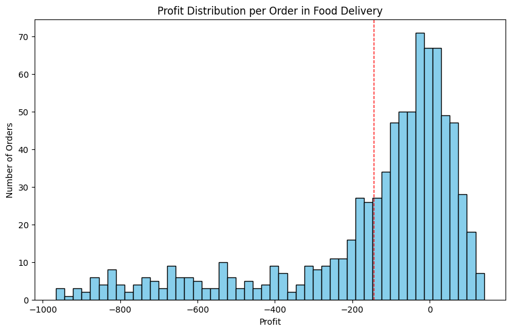

```python
import matplotlib.pyplot as plt
# histogram of profits per order
plt.figure(figsize=(10, 6))
plt.hist(food_orders['Profit'], bins=50, color='skyblue', edgecolor='black')
plt.title('Profit Distribution per Order in Food Delivery')
plt.xlabel('Profit')
plt.ylabel('Number of Orders')
plt.axvline(food_orders['Profit'].mean(), color='red', linestyle='dashed', linewidth=1)
plt.show()
```

##### Profit Rollercoaster: A Closer Look

The histogram paints a clear picture: profits per order are all over the map.  
There's a concerning number of orders falling below the red dashed line, which represents the average profit – and guess what? It's negative!  
This confirms what we already saw – overall, we're losing money on deliveries.  
Now, let’s have a look at the proportion of total costs:

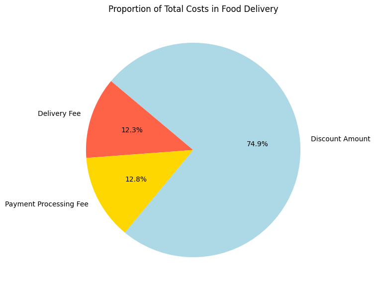

```python
# pie chart for the proportion of total costs
costs_breakdown = food_orders[['Delivery Fee', 'Payment Processing Fee', 'Discount Amount']].sum()
plt.figure(figsize=(7, 7))
plt.pie(costs_breakdown, labels=costs_breakdown.index, autopct='%1.1f%%', startangle=140, colors=['tomato', 'gold', 'lightblue'])
plt.title('Proportion of Total Costs in Food Delivery')
plt.show()
```

The pie chart slices up our total costs into delivery fees, payment processing fees, and discounts.  
One slice stands out: discounts! It seems our generous promotions might be a major culprit behind the profitability slump.  
Now, let’s compare total revenue, total costs, and total profit (net loss in our case):

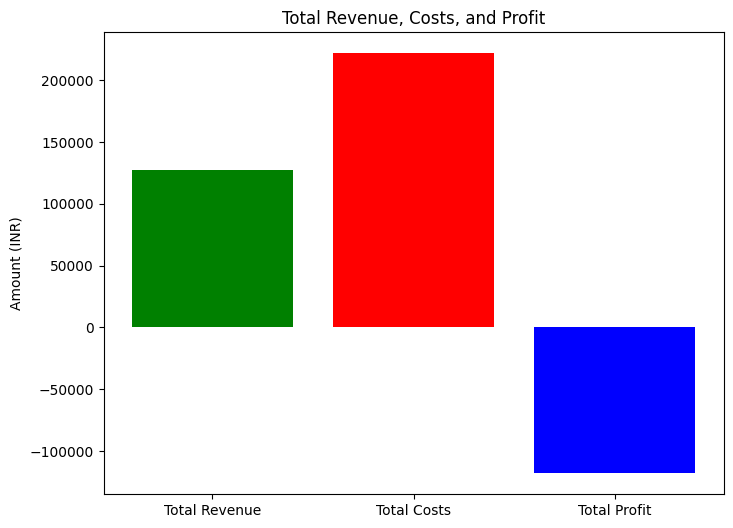

```python
# bar chart for total revenue, costs, and profit
totals = ['Total Revenue', 'Total Costs', 'Total Profit']
values = [total_revenue, total_costs, total_profit]

plt.figure(figsize=(8, 6))
plt.bar(totals, values, color=['green', 'red', 'blue'])
plt.title('Total Revenue, Costs, and Profit')
plt.ylabel('Amount (INR)')
plt.show()
```

The bar chart brings everything together. It shows total revenue, total costs, and – you guessed it – total profit (or in our case, the lack thereof).  
This visual makes it clear: our costs are outpacing revenue, resulting in a significant overall loss.

##### Turning the Tide: Strategies for Profitability

Our analysis has revealed a key culprit behind our losses: discounts on food orders. To steer towards profitability, we need a new game plan for discounts and commissions.

The ideal scenario is finding a sweet spot – a balance where we can offer attractive discounts without sacrificing profits. To achieve this, let's delve deeper into the characteristics of profitable orders. Specifically, we're looking for:

- A new average commission percentage based on profitable orders.
- A new average discount percentage for profitable orders, that could serve as a guideline for what level of discount still allows for profitability.

By identifying these averages, we can develop adjustments that not only make individual orders profitable but also improve our overall profitability across the board.

```python
# filter the dataset for profitable orders
profitable_orders = food_orders[food_orders['Profit'] > 0]

# calculate the average commission percentage for profitable orders
profitable_orders['Commission Percentage'] = (profitable_orders['Commission Fee'] / profitable_orders['Order Value']) * 100

# calculate the average discount percentage for profitable orders
profitable_orders['Effective Discount Percentage'] = (profitable_orders['Discount Amount'] / profitable_orders['Order Value']) * 100

# calculate the new averages
new_avg_commission_percentage = profitable_orders['Commission Percentage'].mean()
new_avg_discount_percentage = profitable_orders['Effective Discount Percentage'].mean()

print(new_avg_commission_percentage, new_avg_discount_percentage)
```

```
36.99030453177021 9.938775510204081
```

[output not shown]

Based on the analysis of profitable orders, we find a new set of averages that could represent a “sweet spot” for commission and discount percentages:

Our analysis has unearthed some golden nuggets of information:

- **Commission Sweet Spot:** The average commission percentage for profitable orders is significantly higher than the overall average. This suggests that increasing commission rates could be a game-changer for profitability.
- **Discount Discipline:** We also found that profitable orders tend to have lower average discount percentages compared to all orders. This indicates that strategic discounting, without going overboard, can contribute to profitability without scaring away customers.

In short, these findings suggest a two-pronged approach to profitability: raising commission rates strategically and implementing smarter discount practices.

Now, let's put our insights into action and see how they might impact profitability across all orders. We'll do this by visualizing a comparison:

By comparing these two scenarios visually, we'll gain a clear understanding of how adopting the recommended discount and commission rates could improve the overall profitability of our orders.

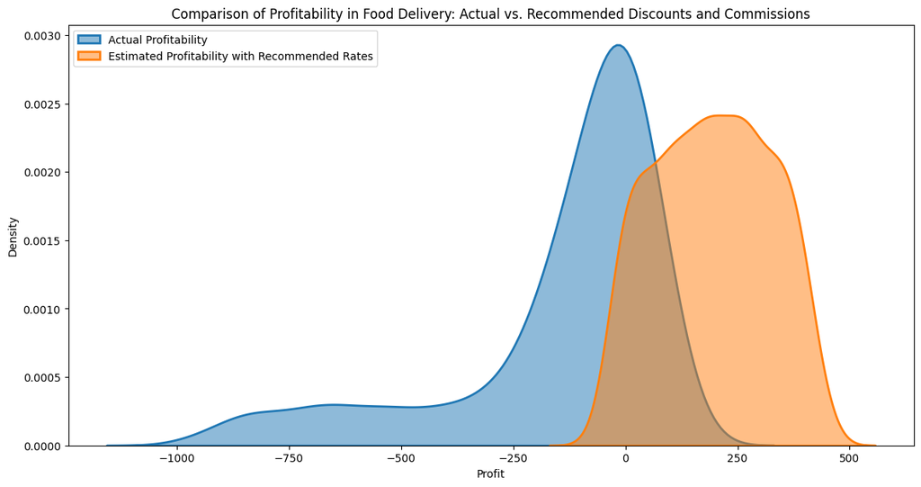

```python
# simulate profitability with recommended discounts and commissions
recommended_commission_percentage = 30.0  # 30%
recommended_discount_percentage = 6.0    # 6%

# calculate the simulated commission fee and discount amount using recommended percentages
food_orders['Simulated Commission Fee'] = food_orders['Order Value'] * (recommended_commission_percentage / 100)
food_orders['Simulated Discount Amount'] = food_orders['Order Value'] * (recommended_discount_percentage / 100)

# recalculate total costs and profit with simulated values
food_orders['Simulated Total Costs'] = (food_orders['Delivery Fee'] +
                                        food_orders['Payment Processing Fee'] +
                                        food_orders['Simulated Discount Amount'])

food_orders['Simulated Profit'] = (food_orders['Simulated Commission Fee'] -
                                   food_orders['Simulated Total Costs'])

# visualizing the comparison
import seaborn as sns

plt.figure(figsize=(14, 7))

# actual profitability
sns.kdeplot(food_orders['Profit'], label='Actual Profitability', fill=True, alpha=0.5, linewidth=2)

# simulated profitability
sns.kdeplot(food_orders['Simulated Profit'], label='Estimated Profitability with Recommended Rates', fill=True, alpha=0.5, linewidth=2)

plt.title('Comparison of Profitability in Food Delivery: Actual vs. Recommended Discounts and Commissions')
plt.xlabel('Profit')
plt.ylabel('Density')
plt.legend(loc='upper left')
plt.show()
```

##### The Profitability Picture: Before & After

This visualization compares profitability across all orders under two conditions:

The current profitability distribution is a mixed bag. We see a significant portion of orders landing in the red (profitability less than zero), with a wide range of profit levels for profitable orders. However, the simulated scenario paints a brighter picture. The distribution shifts towards higher profitability, with a clear bias towards positive profits. This suggests that the recommended adjustments have the potential to significantly increase the number of profitable orders.

Summary

Ever wondered how profitable your food delivery service is? This analysis dives deep into every aspect of your operation, from delivery fees to customer discounts, to reveal exactly where your money goes and where you can tighten things up. By comparing your costs (including packaging, fees, and discounts) with the revenue you earn (mainly from order value and commission fees), we can pinpoint the profitability of each order.

This step-by-step approach will give you a crystal-clear picture of your financial health:

1. Data Collection: We'll gather detailed information about every aspect of your food delivery service.
2. Data Cleaning: We'll ensure your data is accurate and organized for smooth analysis.
3. Cost Breakdown: We'll categorize all the expenses associated with each order.
4. Revenue Analysis: We'll determine the income generated from each order, focusing on commission fees and the order value before any discounts.
5. Profitability Assessment: We'll calculate the profit for each order by subtracting the total costs from the revenue. Analyzing this data will reveal trends in profitability across all orders.
6. Strategic Recommendations: Based on the analysis, we'll develop strategies to boost your profitability.
7. Financial Impact Simulation: We'll use the data to predict the financial outcome of proposed changes, such as adjusting discount or commission rates.

By following these steps, you'll gain valuable insights to optimize your food delivery business and watch your profits soar!